# Tutorial 01_01: Statistica descrittiva e esplorazione dei dati

## Interpretazione della deviazione standard

La deviazione standard può essere interpretata dicendo che, nel caso di dati che seguono la distribuzione Normale, la deviazione standard è pari a circa 1.5 volte la *deviazione mediana assoluta*:

$${\displaystyle \operatorname {MAD} =\operatorname {median}
(|X_{i}-{\tilde {X}}|)},$$

ovvero

$${\displaystyle {\hat {\sigma }}=k\cdot \operatorname {MAD} ,}$$
con $k \approx 1.4826$.

Nel caso presente, i valori BDI **non** seguono la distribuzione Normale, per cui l’eguaglianza precedente non vale.

Esaminiamo invece un caso nel quale tale proprietà è valida. Creo un campione di osservazioni che seguono la distribuzione Normale:

```r
n <- 1e4
x <- rnorm(n, 100, 15)
x[1:10]
```

```
##  [1] 112.65266  75.35579  98.52276 118.94847 124.13782  87.38115 111.01318
##  [8]  76.17351  85.97850  79.72871
```

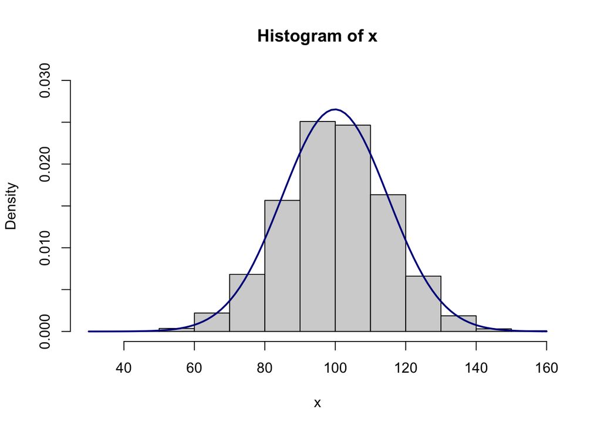

```r
hist(x, freq = FALSE, ylim = c(0, 0.03))
mx <- mean(x)
sdx <- sd(x)
curve(
  dnorm(x, mean=mx, sd=sdx),
  col="darkblue", lwd=2, add=TRUE, yaxt="n"
)
```

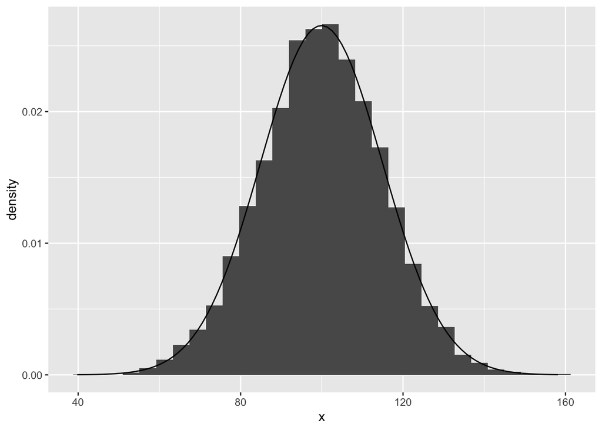

```r
df <- tibble(x)
df %>%
  ggplot(aes(x = x)) +
  geom_histogram(aes(y =..density..)) +
  stat_function(fun = dnorm, args = list(mean = mean(df$x), sd = sd(df$x)))
```

```r
sd(x)
```

```
## [1] 15.03189
```

```r
MAD <- median(abs(x - median(x)))
MAD
```

```
## [1] 10.07166
```

```r
1.4826 * MAD
```

```
## [1] 14.93224
```

## Quantili

Si trovi il terzo quartile della distribuzione dei valori `bdi`.

```r
# inserisci il codice qui
quantile(bdi, 0.75)
```

```
##  75%
## 29.5
```

Ci aspettiamo che, in base alla definizione di quartile, sotto il terzo quarile si situino il 75% dei valori della distribuzione. Nel nostro caso abbiamo 66 valori e il 75% di 66 è

```r
66 * 0.75
```

```
## [1] 49.5
```

ovvero 50 valori. Il terzo quartile è 29.5.

Contiamo dunque quanti elementi del vettore `bdi` hanno un valore minore di 29.5 per verificare se il risultato fornito da R ha senso.

(Suggerimento. Per risolvere questo problema, possiamo utilizzare l’espressione `bdi < 29.5`. Questa è una proposizione logica che significa: “ciascun elemento del vettore `bdi` soddisfa la condizione `< 20.5`”. Questa proposizione può essere VERA o FALSA per ciascun elemento di `bdi`. Infatti, se scriviamo `bdi < 29.5`, R ritorna un vettore di ordine 66, i cui elementi hanno modalità TRUE o FALSE. Questo vettore ci dice, per ciascun elemento di `bdi`, se la condizione `< 29.5` è soddisfatta oppure no. Il vettore risultate contiene una variabile **booleana**, ovvero una variabile che assume valori booleani, cioè Vero|Falso, True|False, o 1|0. TRUE vale 1 e FALSE vale 0. Possiamo dunque eseguire delle operazioni aritmetiche su tali valori booleani. Per esempio, per trovare il numero di volte nelle quali la condizione `< 29.5` è soddisfatta, basta sommare i valori booleani del vettore che abbiamo trovato.)

```r
# inserisci il codice qui
length(bdi[bdi < 29.5])
```

```
## [1] 49
```

Non male! Abbiamo un numero **finito** di valori, dunque non possiamo ottenere esattamente un risultato pari al 75%. Ma andiamo molto vicino.

## Box plot

Costruiamo ora un box-plot con i valori `bdi`. È sufficiente usare la funzione `boxplot()`.

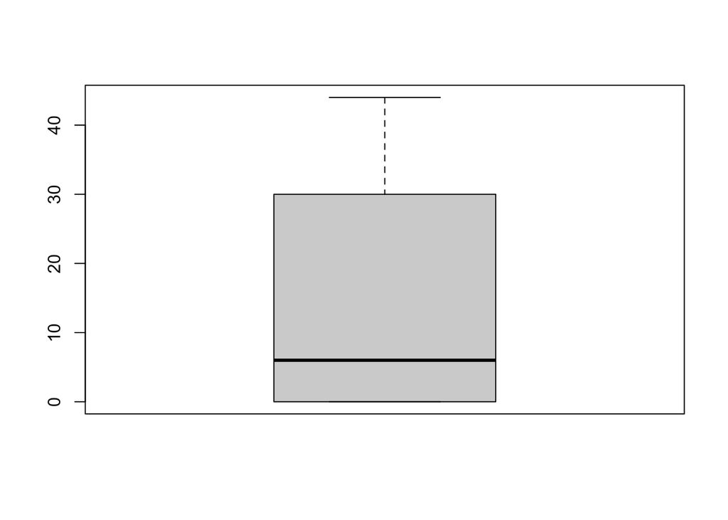

```r
# inserisci il codice qui
boxplot(bdi)
```

Qui non c’è molto di interessante che possiamo fare, dato che è chiaro che il valore dell’unico “baffo” (segmento!) del box-plot è uguale al massimo della distribuzione:

```r
# inserisci il codice qui
max(bdi)
```

```
## [1] 44
```

Per rendere più interessane il problema, consideriamo una diversa distribuzione nella quale ci sono alcuni valori anomali. Immaginiamo di avere 30 valori estratti a caso dalla distribuzione del quoziente di intelligenza. A tali 30 valori ci aggiungiamo due valori che sono più alti di quelli che si incontrano “normalmente” (160, 165).

Nelle istruzioni seguenti, `set.seed(123)` consente la riproducibilità dei risultati. La funzione `rnorm(30, 100, 15)` prende 30 valori a caso dalla popolazione di valori del quoziente di intelligenza (vedremo in seguito come i valori del quoziente di intelligenza seguono una determinata distribuzione teorica detta normale o gaussiana di media 100 e deviazione standard 15). La funzione `round` elimina la componente decimale, in quanto il quoziente di intelligenza è un numero intero. La funzione `c()` crea un vettore nel quale aggiungiamo i due elementi che abbiamo specificato (160, 165) ai 30 creati da `rnorm(30, 100, 15)`:

```r
set.seed(123)
iq <- c(round(rnorm(30, 100, 15)), 160, 165)
iq
```

```
##  [1]  92  97 123 101 102 126 107  81  90  93 118 105 106 102  92 127 107  71 111
## [20]  93  84  97  85  89  91  75 113 102  83 119 160 165
```

Creaiamo il box-plot per i 32 valori della variabile `iq`:

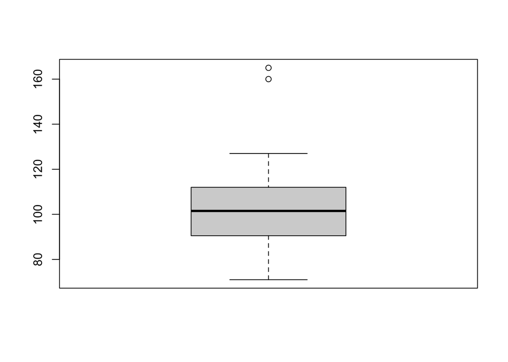

```r
# inserisci il codice qui
boxplot(iq)
```

Ora il “baffo superiore” non coincide con il massimo della distribuzione. Si trovi il valore del punto che si trova all’estremità del baffo superiore.

```r
# inserisci il codice qui
median(iq) + 1.5 * IQR(iq)
```

```
## [1] 132.625
```

```r
sort(iq)
```

```
##  [1]  71  75  81  83  84  85  89  90  91  92  92  93  93  97  97 101 102 102 102
## [20] 105 106 107 107 111 113 118 119 123 126 127 160 165
```

Verifichiamo che la risposta trovata sia corretta

```r
out <- boxplot(iq, plot = FALSE)
out
```

```
## $stats
##       [,1]
## [1,]  71.0
## [2,]  90.5
## [3,] 101.5
## [4,] 112.0
## [5,] 127.0
##
## $n
## [1] 32
##
## $conf
##          [,1]
## [1,]  95.4949
## [2,] 107.5051
##
## $out
## [1] 160 165
##
## $group
## [1] 1 1
##
## $names
## [1] "1"
```

## Covarianza

Consideriamo ora il livello di depressione misurato dal test CES-D. Sono qui riportati i valori sia del BDI-II sia del CES-D ordinati nella maniera corretta.

```r
bdi <- c(
  26, 35, 30, 25, 44, 30, 33, 43, 22, 43, 24, 19, 39,  3,
  0,  1, 31, 25,  0,  2,  0,  0,  0, 28,  0,  0,  1,  0,
  2, 0,  7, 35,  0,  2, 30,  0, 26,  1,  0,  0, 31,  0,
  1, 41, 36, 26, 35, 33, 12, 28,  1, 27, 34, 27, 22,  1,
  5,  3, 1,  3,  0,  2,  9,  1,  0,  0
)

cesd <- c(
  47, 35, 29, 25, 37, 38, 38, 44, 34, 48, 19, 29, 36, 16,
  12, 5, 15, 38,  9, 16,  0,  5,  6, 34,  5,  7,  2,  8,
  8, 5, 18, 46,  3, 12, 41,  5, 36,  9,  6,  2, 34,  6,
  10, 31, 47, 44, 22, 39, 19, 25,  6, 28, 29, 39, 27,
  0, 10,  4, 6,  8, 13,  3,  7,  5,  6, 10
)
```

Iniziamo con il creare un diagramma a dispersione usando la funzione `ggplot()`. Prima di tutto creaimo un data.frame, perché `ggplot()` richiede un data.frame in input.

```r
d <- tibble(bdi, cesd)
glimpse(d)
```

```
## Rows: 66
## Columns: 2
## $ bdi  <dbl> 26, 35, 30, 25, 44, 30, 33, 43, 22, 43, 24, 19, 39, 3, 0, 1, 31, …
## $ cesd <dbl> 47, 35, 29, 25, 37, 38, 38, 44, 34, 48, 19, 29, 36, 16, 12, 5, 15…
```

Iniziamo con il primo layes:

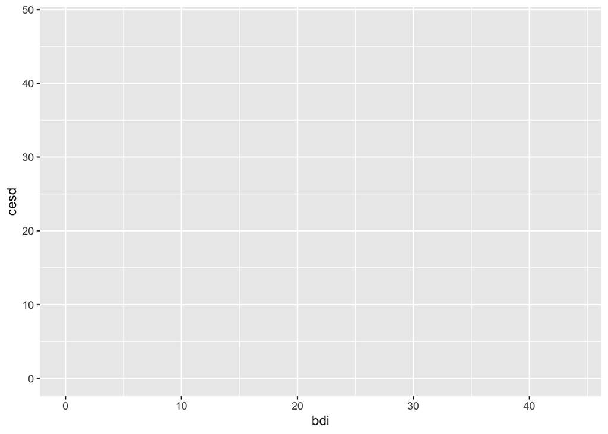

```r
d %>%
  ggplot(
    aes(bdi, cesd)
  )
```

e poi aggiungiamo i punti:

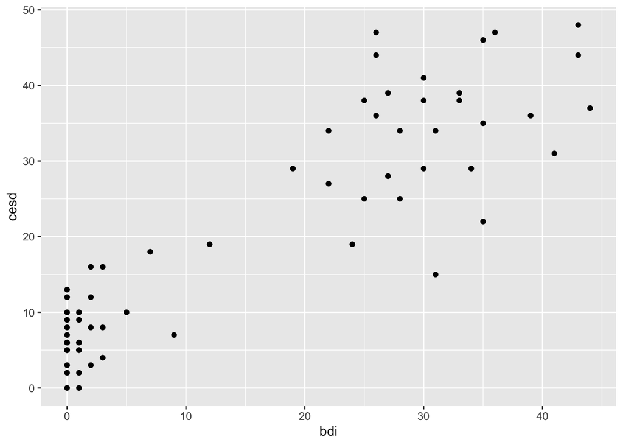

```r
d %>%
  ggplot(
    aes(bdi, cesd)
  ) +
  geom_point()
```

Il diagramma a dispersione mostra che all’aumentare del BDI-II aumenta anche il CES-S. Questo è quello che dovremmo aspettarci in quanto entrambe sono misure dello stesso costrutto, la depressione. L’associazione non è perfetta e ciò è dovuto al fatto che nessun indicatore empirico riflette in maniera perfetta il costrutto. Qualsiasi misura empirica è inquinata dall’*errore di misurazione*.

Iniziamo a calcolare la covarianza:

$$\begin{equation}
S(x, y) = \frac{\sum_{i=1}^n (x_i - \bar{x})(y_i - \bar{y})}{n}
\end{equation}$$

Calcoliamo dunque la covarianza tra i punteggi BDI-II e CES-D:

```r
# inserisci il codice qui
cov_bdi_cesd <- sum((d$bdi - mean(d$bdi)) * (d$cesd - mean(d$cesd))) / nrow(d)
cov_bdi_cesd
```

```
## [1] 207.4265
```

Controlliamo usando la funzione `cov()`. (Suggerimento: anche la funzione `cov()`, come `var()`, usa *n - 1* al denominatore).

```r
# inserisci il codice qui
cov(d$bdi, d$cesd) * 65/66
```

```
## [1] 207.4265
```

Il valore ottenuto è difficile da interpretare. Il segno è positivo, quindi sappiamo che l’associazione è positiva (all’aumentare di *x* aumenta *y*). Ma oltre a questo la covarianza non ci dice altro. Per capire di più dobbiamo usare la correlazione.

## Correlazione

La correlazione è una covarianza standardizzata. Calcoliamo la correlazione tra i punteggi BDI-II e CES-D:

```r
sd1 <- sqrt(var(d$bdi) * 65 / 66)
sd2 <- sqrt(var(d$cesd) * 65 / 66)
r_bdi_cesd <- cov_bdi_cesd / (sd1 * sd2)
r_bdi_cesd
```

```
## [1] 0.904062
```

Controlliamo usando la funzione `cor()`. (Suggerimento: in questo caso non serve correggere il denominatore.)

```r
# inserisci il codice qui
cor(d$bdi, d$cesd)
```

```
## [1] 0.904062
```

Oppure possiamo usare una funzione crea da noi – diversa da quelle usate da R. Definisco qui la funzione my_var() che calcola la varianza con n al denominatore:

```r
my_var <- function(x) {
  var(x) * (length(x) - 1) / length(x)
}
```

```r
cov_bdi_cesd / (sqrt(my_var(d$bdi)) * sqrt(my_var(d$cesd)))
```

```
## [1] 0.904062
```

Oppure ancora, possiamo prima standardizzare le variabili e poi calcolare la covarianza. Iniziamo a definire una funzione che standardizza i valori della variabile in input:

```r
scale_this <- function(x) {
  std <- sqrt(my_var(x))
  (x - mean(x)) / std
}
```

```r
z_bdi <- scale_this(d$bdi)
mean(z_bdi)
```

```
## [1] 1.967498e-17
```

```r
var(z_bdi) * 65 / 66
```

```
## [1] 1
```

```r
z_cesd <- scale_this(d$cesd)
mean(z_cesd)
```

```
## [1] -6.885012e-17
```

```r
var(z_cesd)*65/66
```

```
## [1] 1
```

Adesso calcolo la covarianza tra le variabili standardizzate:

```r
# inserisci il codice qui
sum((z_bdi - mean(z_bdi)) * (z_cesd - mean(z_cesd))) / nrow(d)
```

```
## [1] 0.904062
```

il che, ovviamente, produce l’indice di correlazione.

Se tutte le osservazioni stanno su una retta, la correlazione è 1 oppure -1.

Creando i dati e svolgendo i calcoli, si provi l’affermazione precedente.

```r
# inserisci il codice qui
x <- 1:10
y <- 0.5 * x
cor(x, y)
```

```
## [1] 1
```

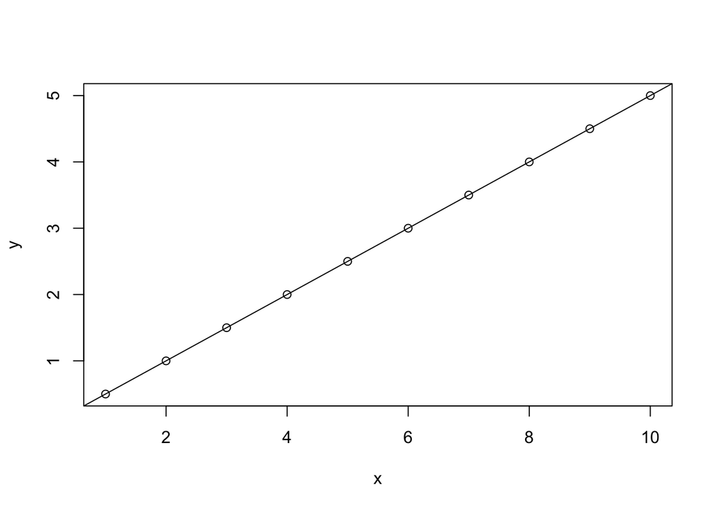

```r
plot(x, y)
abline(0, 0.5)
```

# È necessario guardare i dati!

Le statistiche descrittive forniscono una descrizione sintetica dei dati. Ciò non vuol dire che, una volta calcolate queste statistiche, abbiamo descritto tutte le proprietà dei dati. Qui di seguito è fornito un famoso esempio di una serie di data set con due variabili nei quali le statistiche descrittive (media x, media y, sd x, sd y, cor(x,y)) sono molto simili, ma che corrispondono a situazioni completamente diverse.

Credo un campione di dati “a caso”:

```r
library(MASS)
cov <- -0.06412835 * 16.76982 * 26.93974
Sigma <- matrix(c(16.76982^2, cov, cov, 26.93974^2), 2, 2)

d <- mvrnorm(n = 100, mu = c(54.26610, 47.83472), Sigma, empirical = TRUE)
head(d)
```

```
##          [,1]      [,2]
## [1,] 39.35391  14.20014
## [2,] 58.15575  33.90280
## [3,] 37.07008  52.78964
## [4,] 39.64728  64.30064
## [5,] 48.64815 104.80327
## [6,] 35.78931  23.95095
```

Media e deviazione standard della prima variabile:

```r
mean(d[, 1])
```

```
## [1] 54.2661
```

```r
sd(d[,1])
```

```
## [1] 16.76982
```

Media e deviazione standard della seconda variabile:

```r
mean(d[, 2])
```

```
## [1] 47.83472
```

```r
sd(d[,2])
```

```
## [1] 26.93974
```

Correlazione:

```r
cor(d[,1], d[,2])
```

```
## [1] -0.06412835
```

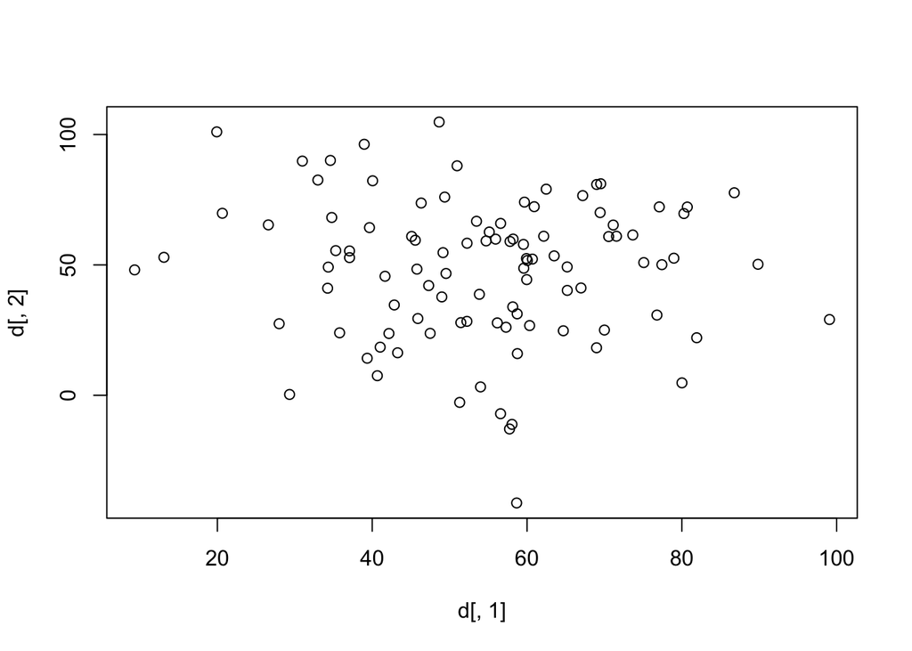

```r
plot(d[,1], d[,2])
```

Ora utilizzo altri data set che producono le stesse statistiche descrittive:

```r
library("datasauRus")
if(requireNamespace("dplyr")){
  suppressPackageStartupMessages(library(dplyr))
  datasaurus_dozen %>%
    group_by(dataset) %>%
    summarize(
      mean_x    = mean(x),
      mean_y    = mean(y),
      std_dev_x = sd(x),
      std_dev_y = sd(y),
      corr_x_y  = cor(x, y)
    )
}
```

```
## # A tibble: 13 × 6
##    dataset    mean_x mean_y std_dev_x std_dev_y corr_x_y
##    <chr>       <dbl>  <dbl>     <dbl>     <dbl>    <dbl>
##  1 away         54.3   47.8      16.8      26.9  -0.0641
##  2 bullseye     54.3   47.8      16.8      26.9  -0.0686
##  3 circle       54.3   47.8      16.8      26.9  -0.0683
##  4 dino         54.3   47.8      16.8      26.9  -0.0645
##  5 dots         54.3   47.8      16.8      26.9  -0.0603
##  6 h_lines      54.3   47.8      16.8      26.9  -0.0617
##  7 high_lines   54.3   47.8      16.8      26.9  -0.0685
##  8 slant_down   54.3   47.8      16.8      26.9  -0.0690
##  9 slant_up     54.3   47.8      16.8      26.9  -0.0686
## 10 star         54.3   47.8      16.8      26.9  -0.0630
## 11 v_lines      54.3   47.8      16.8      26.9  -0.0694
## 12 wide_lines   54.3   47.8      16.8      26.9  -0.0666
## 13 x_shape      54.3   47.8      16.8      26.9  -0.0656
```

Esaminiamo i diagrammi di dispersione:

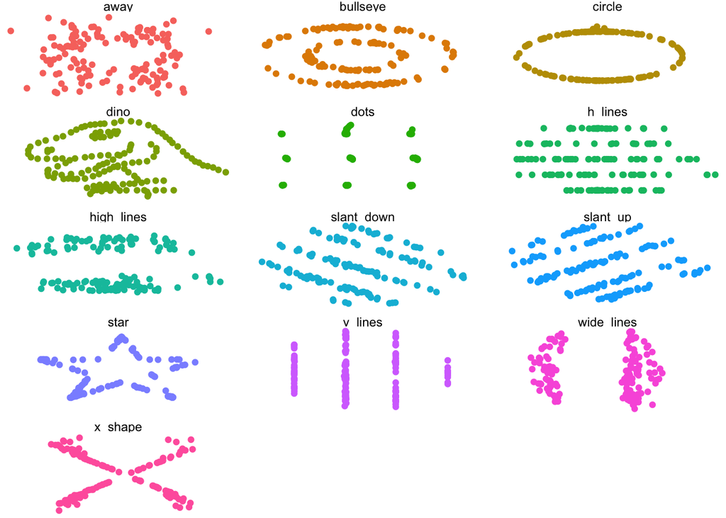

```r
if(requireNamespace("ggplot2")){
  library(ggplot2)
  ggplot(datasaurus_dozen, aes(x=x, y=y, colour=dataset))+
    geom_point()+
    theme_void()+
    theme(legend.position = "none")+
    facet_wrap(~dataset, ncol=3)
}
```

Perché la correlazione è uguale in questi casi molto diversi?